# Team proj 1

Team 6 purple

9/17/2020

## **Part I**

### **1. Introduction**

This analysis’s primary goal is to assess whether receiving job training has a significant effect on annual earnings and what is the range of the effect. Other considerations include whether this effect differs by demographic groups in terms of age, education, and racial identity. We’re also interested in exploring other associations with wages.

### **2. Data**

#### **2.1 Data Pre-Processing**

The original data set is accessed via the NSW Demonstration experiment with 614 non-empty observations. To explore the effect of getting job training on annual wage, we create a numeric variable ‘change’ to quantify the changes in earnings from 1974 to 1978.

#### **2.2 Exploratory Data Analysis**

#### **Response variable vs change in wages**

The distribution of change in earnings follows an approximately normal distribution. Given the boxplot of change in terms of whether the worker gets the job training, we observe a different in the average amount of change in earnings. That is, compared to people without job training, people having job training tends to receive larger increase in income in 1978.

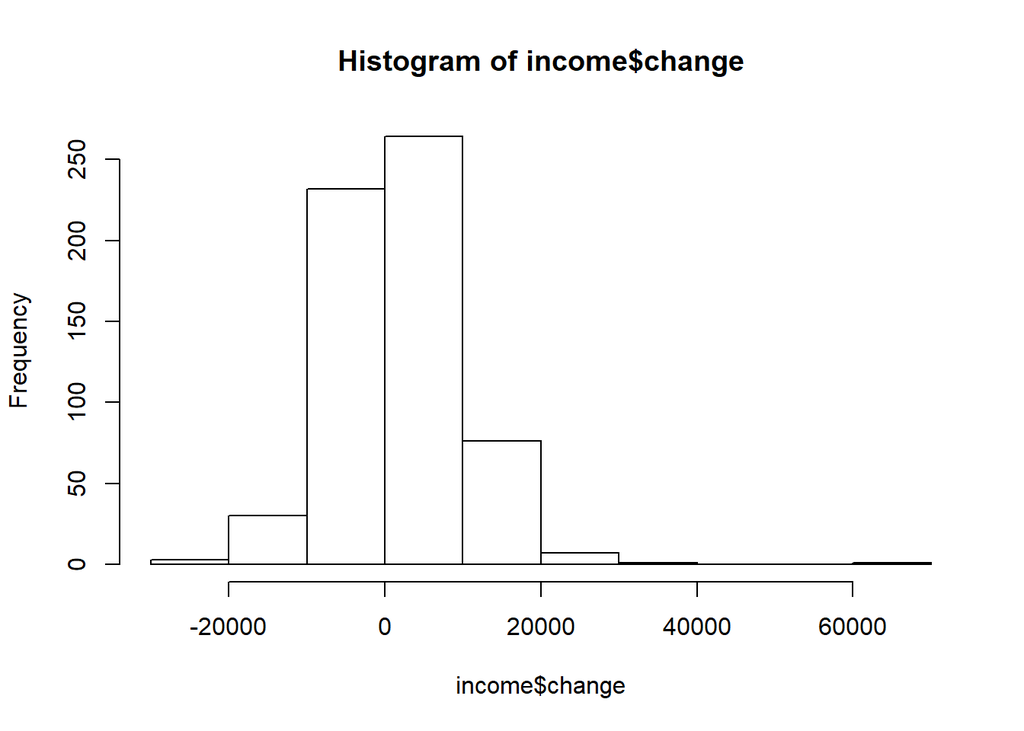

#### **Response variable vs other variables**

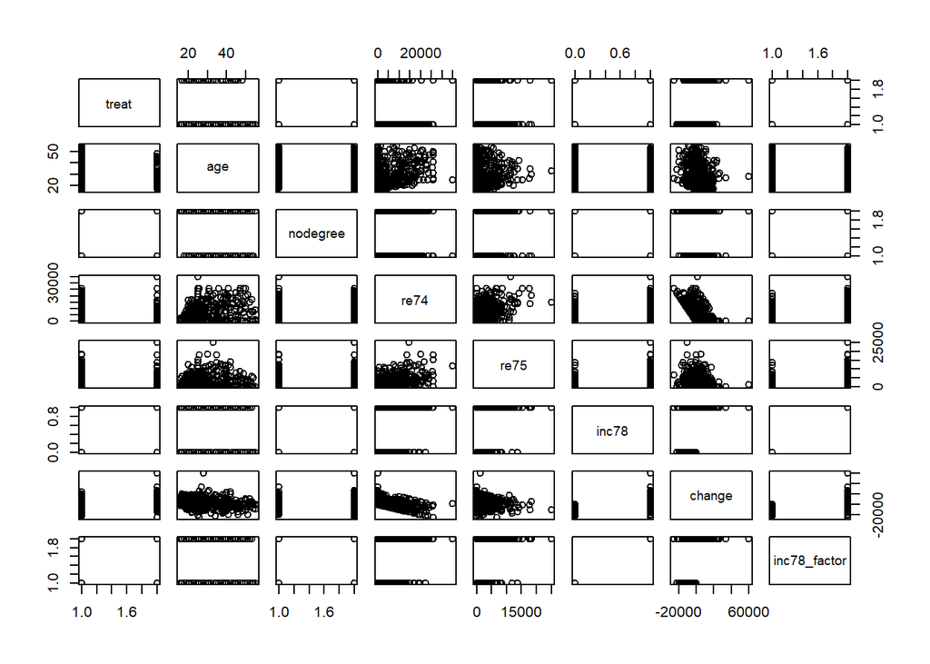

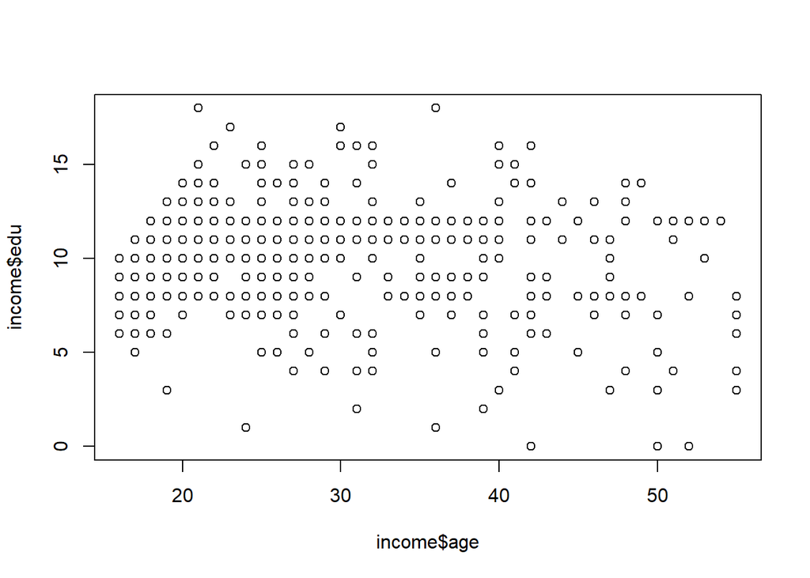

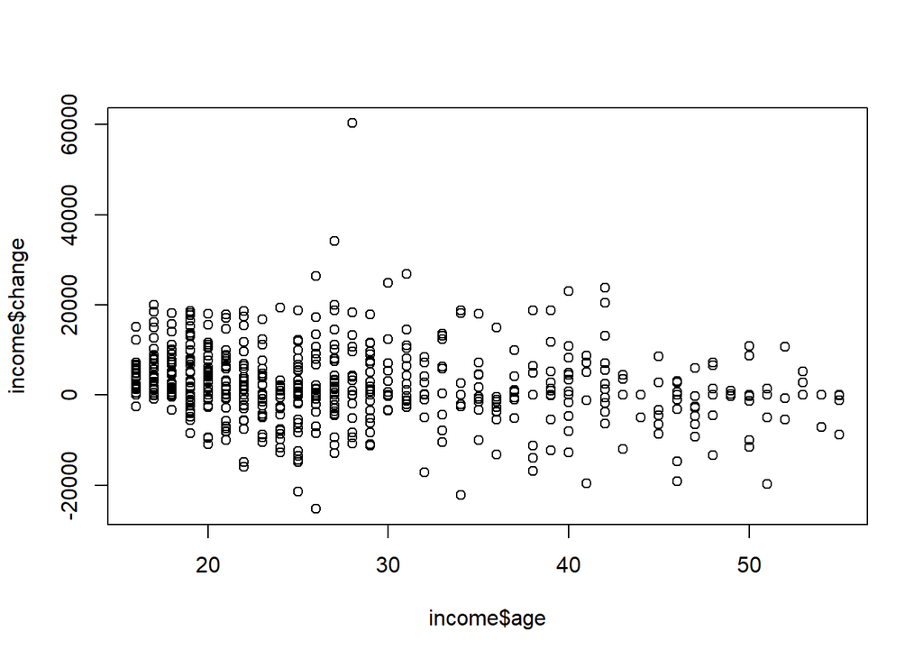

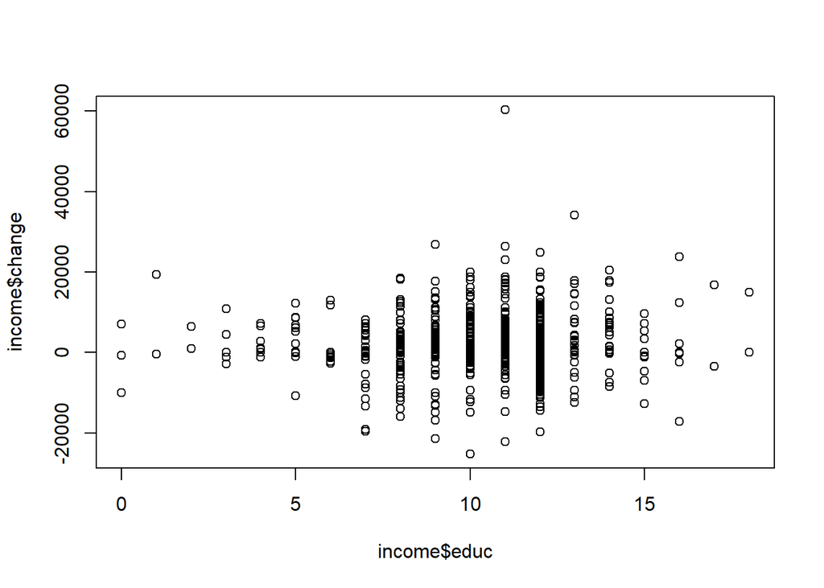

here’s an interesting association between married and change because the difference in mean in the boxplot suggests a decrease in wage when the workers get married compared to those who do not. In terms of numeric variable, the scatter plot between change and age indicates a negative correlated pattern that the average change in wage decreases as the age increases. We will fit both predictors in the model selection process to explore the significance of the effect.

#### **Interactions effect**

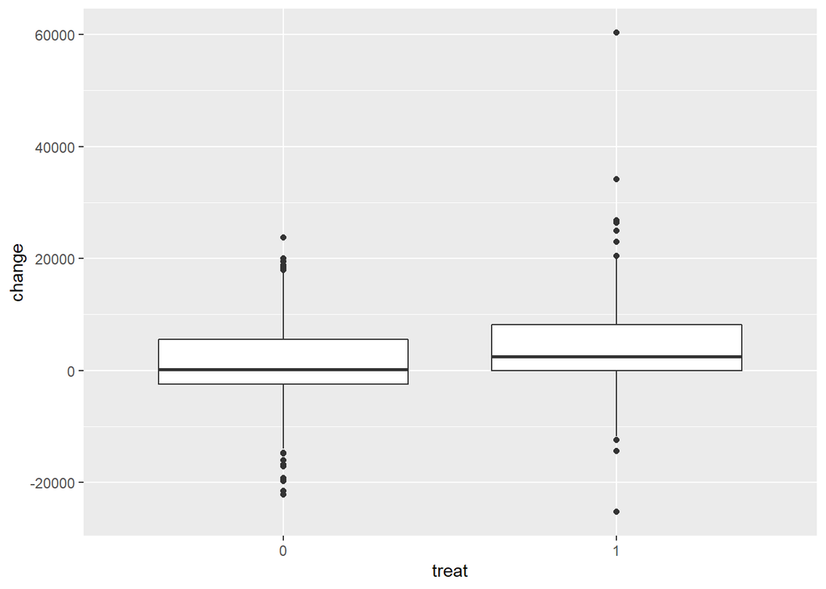

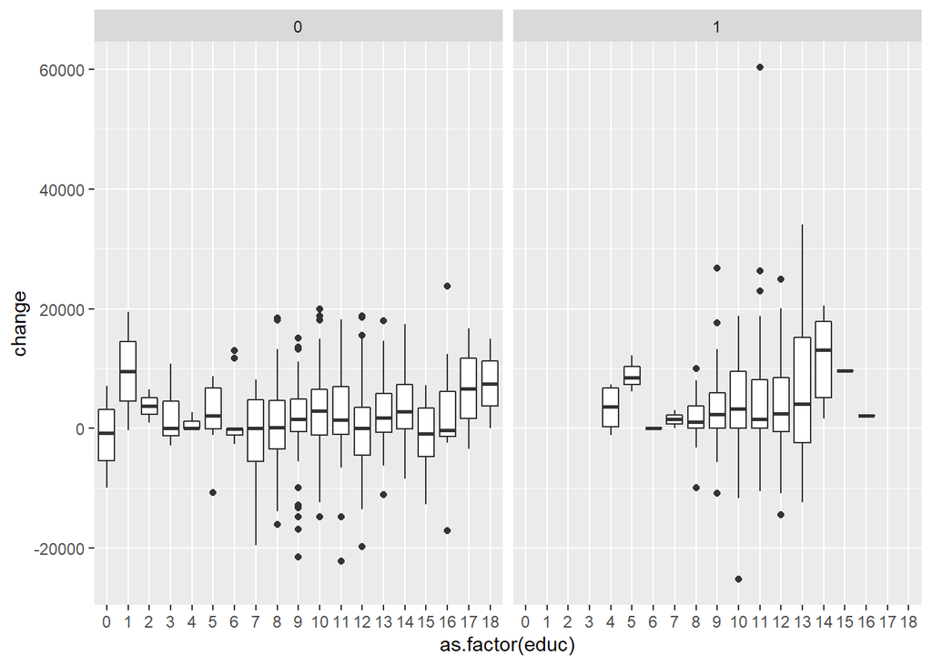

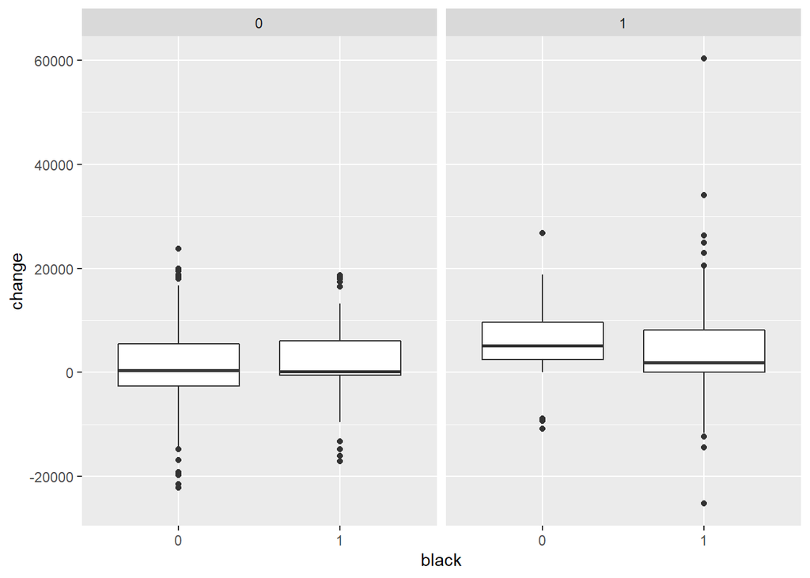

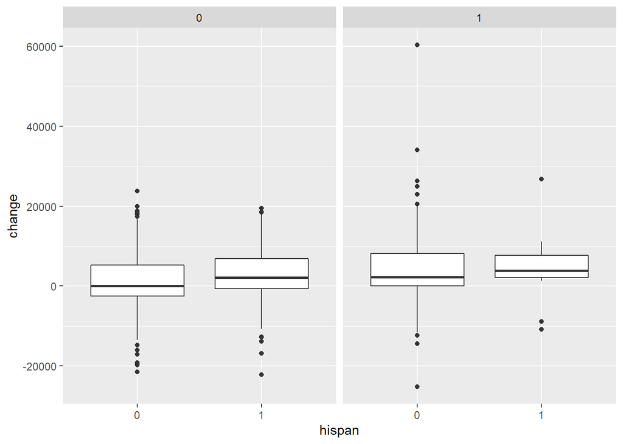

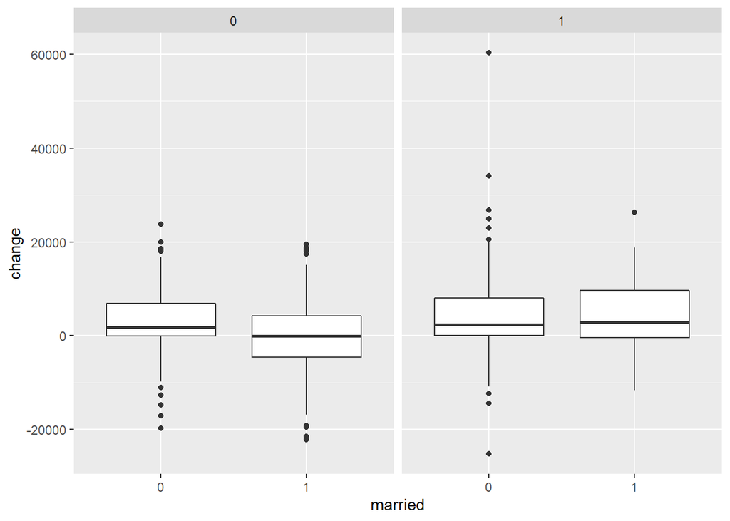

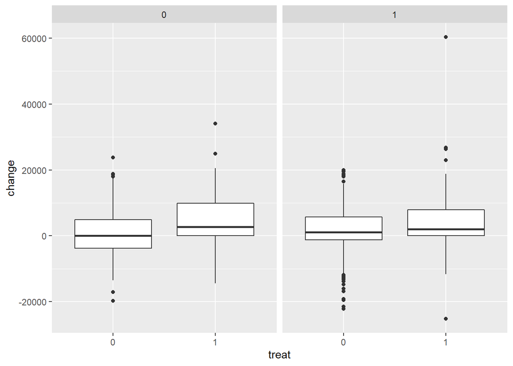

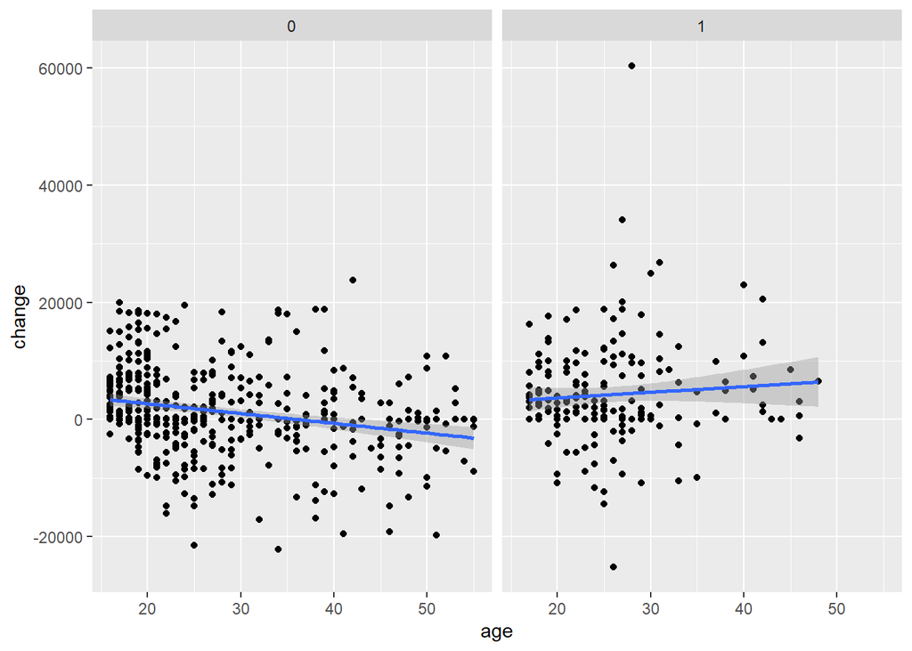

Interaction effects occur when the impact of one variable depends on the value of another variable. In this case, we explore the impact of demographic groups on the association between receiving job training and increasing wages using faced scatter plot and fitted line.

### **3. Model**

#### **3.1 Model Selection**

The model selection is based on two methods: AIC Stepwise Selection and ANOVA chi-square test.

Applying stepwise selection on the full model with all potential predictor and a null model containing only treatment as a predictor, we are able to combine the forward and backward selection and pick the most significant variables by either adding or removing variables several times to meet the maximum likelihood estimation. The final stepwise regression we get includes three significant variables – treatment, age and married. Additional variables and interaction terms is added to the existed model one by one and test their efficiency through the ANOVA Chi-square test.

```
##
## Call:
## lm(formula = change ~ treat + age + married, data = income)
##
## Coefficients:
## (Intercept)       treat1          age     married1
##     4933.27      2085.12       -93.59     -1842.51
```

```
## Analysis of Variance Table
##
## Model 1: change ~ treat + age + married
## Model 2: change ~ treat + age + married + nodegree + nodegree:treat
##   Res.Df        RSS Df Sum of Sq      F Pr(>F)
## 1    610 3.7148e+10
## 2    608 3.7110e+10  2  38180456 0.3128 0.7315
```

```
## Analysis of Variance Table
##
## Model 1: change ~ treat + age + married
## Model 2: change ~ treat + age + married + married:treat
##   Res.Df        RSS Df Sum of Sq      F Pr(>F)
## 1    610 3.7148e+10
## 2    609 3.7053e+10  1  94719655 1.5568 0.2126
```

```
## Analysis of Variance Table
##
## Model 1: change ~ treat + age + married
## Model 2: change ~ treat + age + married + black
##   Res.Df        RSS Df Sum of Sq      F Pr(>F)
## 1    610 3.7148e+10
## 2    609 3.7107e+10  1  40720563 0.6683  0.414
```

```
## Analysis of Variance Table
##
## Model 1: change ~ treat + age + married
## Model 2: change ~ treat + age + married + black + black:treat
##   Res.Df        RSS Df Sum of Sq      F Pr(>F)
## 1    610 3.7148e+10
## 2    608 3.7073e+10  2  74804669 0.6134 0.5418
```

```
## Analysis of Variance Table
##
## Model 1: change ~ treat + age + married
## Model 2: change ~ treat + age + married + nodegree
##   Res.Df        RSS Df Sum of Sq      F Pr(>F)
## 1    610 3.7148e+10
## 2    609 3.7142e+10  1   5447551 0.0893 0.7651
```

```
## Analysis of Variance Table
##
## Model 1: change ~ treat + age + married
## Model 2: change ~ treat + age + married + treat:age
##   Res.Df        RSS Df Sum of Sq      F   Pr(>F)
## 1    610 3.7148e+10
## 2    609 3.6630e+10  1 517774756 8.6083 0.003472 **
## ---
## Signif. codes:  0 '***' 0.001 '**' 0.01 '*' 0.05 '.' 0.1 ' ' 1
```

#### **3.2 Final Model**

In our final model, treatment, married, age and the interaction effects between age and treatments are four significant predictors for predicting the changes annual earnings from 1974 to 1978, using a threshold of 0.1. The R-square of the model is 0.074 which means that the model explains 7.4% of the variability in the data.

*Association suggested by the final model*

— There’s a strong association between married and changes in annual wages. Keep other variables the constant, compared to people who did not get married, people who did, in average, tend to have 1756.52 dollars decrease in annual earnings.

```
##     treat       age   married treat:age
## 12.211141  1.370724  1.269779 12.084833
```

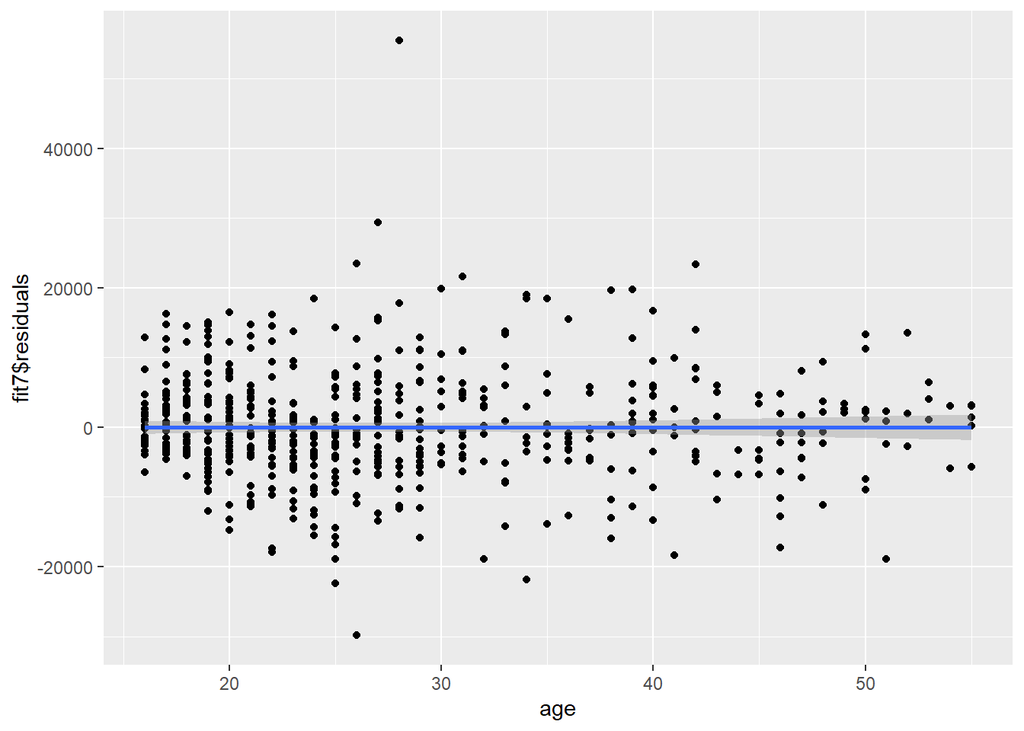

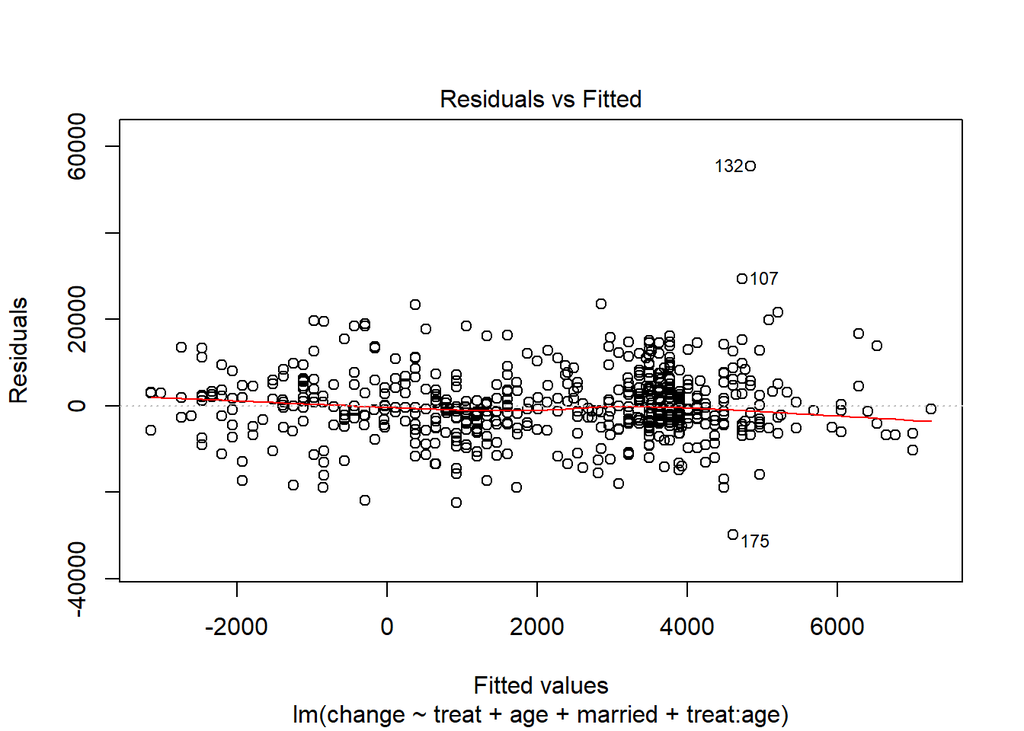

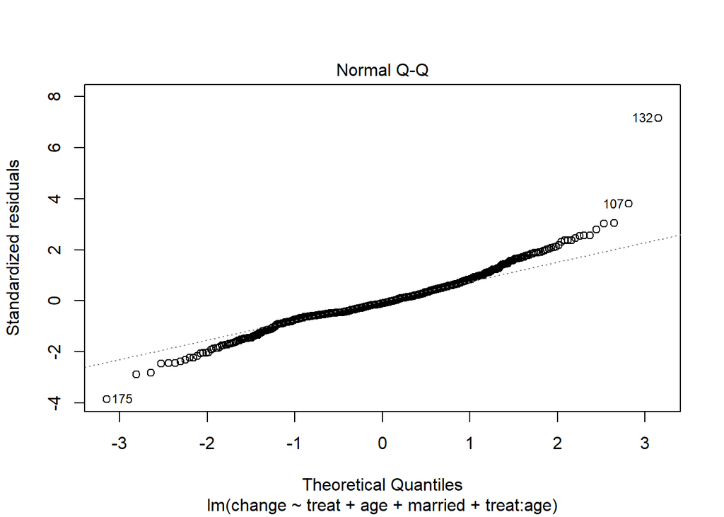

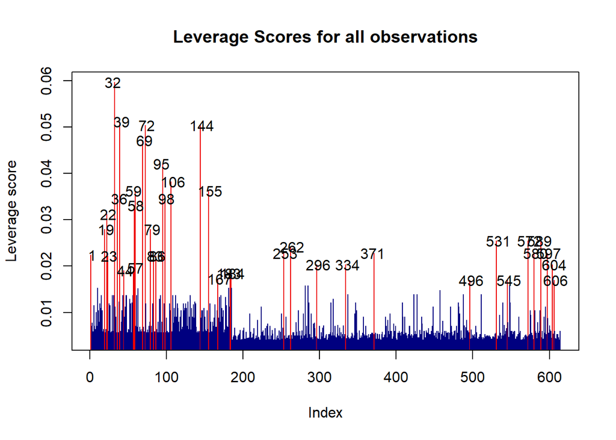

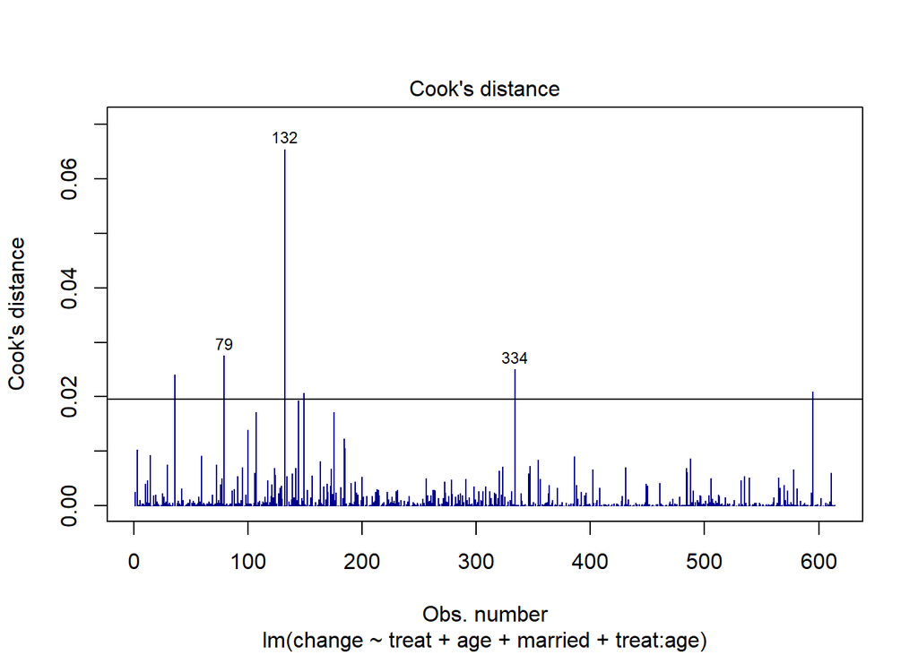

```
##
## Call:
## lm(formula = change ~ treat + age + married + treat:age, data = income)
##
## Residuals:
##    Min     1Q Median     3Q    Max
## -29865  -4125   -766   3846  55460
##
## Coefficients:
##             Estimate Std. Error t value Pr(>|t|)
## (Intercept)  6072.02    1043.64   5.818 9.62e-09 ***
## treat1      -4586.31    2383.74  -1.924 0.054820 .
## age          -135.79      37.11  -3.659 0.000275 ***
## married1    -1756.52     715.72  -2.454 0.014399 *
## treat1:age    255.88      87.21   2.934 0.003472 **
## ---
## Signif. codes:  0 '***' 0.001 '**' 0.01 '*' 0.05 '.' 0.1 ' ' 1
##
## Residual standard error: 7756 on 609 degrees of freedom
## Multiple R-squared:  0.07408,    Adjusted R-squared:  0.068
## F-statistic: 12.18 on 4 and 609 DF,  p-value: 1.561e-09
```

```
##                    5 %       95 %
## (Intercept)  4352.7611 7791.27680
## treat1      -8513.1854 -659.44162
## age          -196.9339  -74.65134
## married1    -2935.5596 -577.47204
## treat1:age    112.2100  399.54817
```

#### **3.3 Model Assessment**

```
##
## Call:
## lm(formula = change ~ treat + age + married + treat:age, data = cleaned)
##
## Residuals:
##      Min       1Q   Median       3Q      Max
## -29457.8  -3959.8   -688.1   3820.1  29817.9
##
## Coefficients:
##             Estimate Std. Error t value Pr(>|t|)
## (Intercept)  5869.48     994.21   5.904 5.92e-09 ***
## treat1      -3758.29    2278.94  -1.649 0.099637 .
## age          -127.14      35.54  -3.578 0.000374 ***
## married1    -1747.42     682.80  -2.559 0.010734 *
## treat1:age    207.52      83.66   2.480 0.013394 *
## ---
## Signif. codes:  0 '***' 0.001 '**' 0.01 '*' 0.05 '.' 0.1 ' ' 1
##
## Residual standard error: 7365 on 606 degrees of freedom
## Multiple R-squared:  0.068,  Adjusted R-squared:  0.06185
## F-statistic: 11.05 on 4 and 606 DF,  p-value: 1.168e-08
```

```
##     treat       age   married treat:age
## 12.273681  1.376638  1.277019 12.137444
```

#### **3.4 Model Validation**

```
## [1] 7707.128
```

```
## [1] 7750.631
```

## **Part II**

### **1. Introduction**

This analysis’s primary goal is to assess whether receiving job training has a significant result in the possibility of receiving a non-zero wage. Other considerations include whether this effect differs by demographic groups in terms of age, education, and racial identity. We’re also interested in exploring other associations with positive income.

### **2. Data**

### **2.1 Data Preprocessing**

The original data set is accessed via the NSW Demonstration experiment with 614 non-empty observations. Since this analysis features the possibility of getting a paid job, we create a binary variable ‘inc78’ where 0 represents zero wages, and 1 indicates positive income. The factorized variable ‘inc78_factor’ will be used as our response variable for analysis and modeling. The cleaned dataset included 6 categorical variables and 1 discrete variable.

### **2.2 Exploratory Data Analysis**

To get a general understanding of the baseline probability for model fitting and further analysis and examine the sufficiency of observations for both levels, we conduct a table of the response variables `inc78_factor`. According to the table, among the 614 participants, the average possibility of getting a non-zero wage job in 1978 is around 76%.

#### **Response variable vs other predictors**

Regarding other categorical variables, the association between Black and Non-zero income seems to be significant according to the conditional probability table. There’s a lower conditional possibility of having non-zero wage when the worker’s racial identity is Black, compared to workers in other racial groups. Even though there’s a difference between the non-Hispanic and Hispanic groups, the change could result from insufficient observations on Hispanic workers. Since no significant change in the possibilities cross different levels is observed in ‘married’ and ‘nondegree,’ they might be pool predictor for predicting the non-zero wage rate. Still, possible interaction effects will be tested later.

```
##             treat
## inc78_factor         0         1
##            0 0.2284382 0.2432432
##            1 0.7715618 0.7567568
```

```
##             black
## inc78_factor         0         1
##            0 0.1994609 0.2839506
##            1 0.8005391 0.7160494
```

```
##             hispan
## inc78_factor         0         1
##            0 0.2416974 0.1666667
##            1 0.7583026 0.8333333
```

```
##             married
## inc78_factor         0         1
##            0 0.2423398 0.2196078
##            1 0.7576602 0.7803922
```

```
##             nodegree
## inc78_factor        0         1
##            0 0.215859 0.2428941
##            1 0.784141 0.7571059
```

```
##             educ
## inc78_factor         0   1 2   3         4          5         6         7
##            0 0.3333333 0.5 0 0.4 0.3333333 0.08333333 0.5833333 0.3703704
##            1 0.6666667 0.5 1 0.6 0.6666667 0.91666667 0.4166667 0.6296296
##             educ
## inc78_factor         8         9       10        11        12        13
##            0 0.3064516 0.1690141 0.183908 0.2315789 0.2165605 0.2592593
##            1 0.6935484 0.8309859 0.816092 0.7684211 0.7834395 0.7407407
##             educ
## inc78_factor        14  15   16 17  18
##            0 0.0952381 0.3 0.25  0 0.5
##            1 0.9047619 0.7 0.75  1 0.5
```

#### **Interaction effect**

Interaction effects occur when the impact of one variable depends on the value of another variable. Conditional possibility tables and faceted boxplots are used to test the interaction effect between terms.

Given whether the participants received job training, the visualized change on the correlation between non-zero wage and age indicates a possible interaction effect between treatment and age. The benefit of job training increases as the worker increases in age, and the net effects of training and age on the possibility of getting a non-zero wage shift from negative to zero, and possibly positive after a certain age.

Another notable interaction is between age and degree as the association between inc78_factor and age change significantly, moving from groups with high school degrees to groups without. The possibility of getting paid employment tends to stay the same, and even increases as a worker with a high school degree grow older, while the possibility decrease as one without a high school degree.

To draw a solid conclusion on interaction terms’ impact, we will determine their efficiency in the modeling selection process.

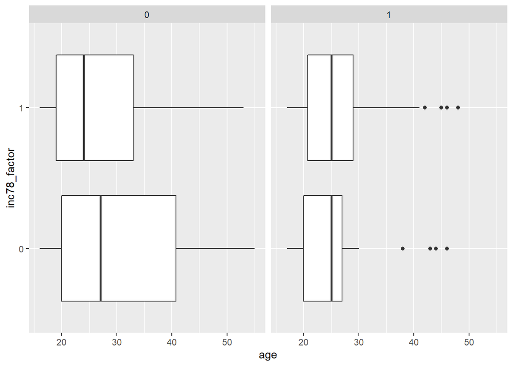

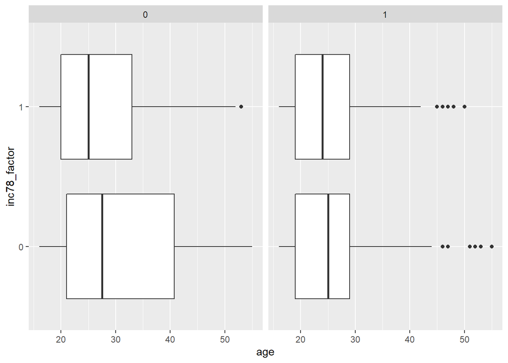

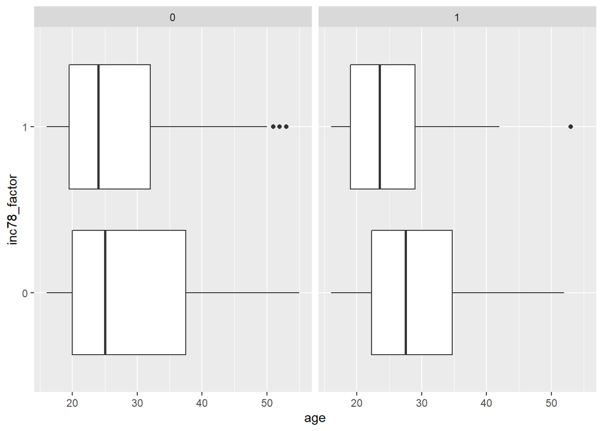

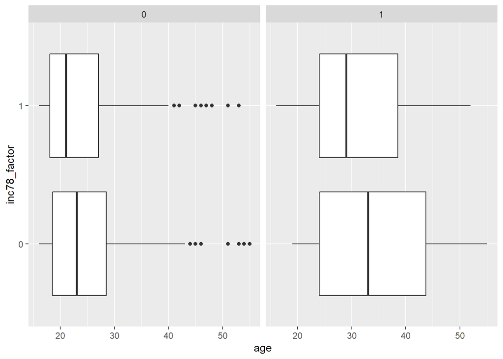

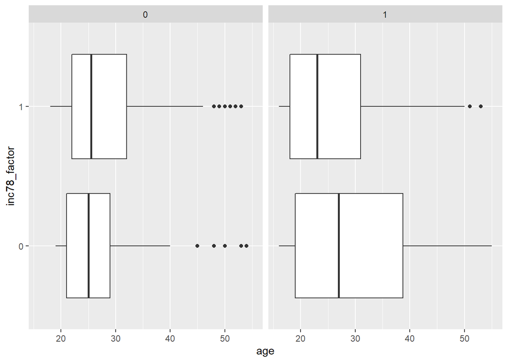

```
##
##  Pearson's Chi-squared test
##
## data:  table(income[, c("nodegree", "age")])
## X-squared = 107.56, df = 39, p-value = 2.479e-08
```

```
##
##  Pearson's Chi-squared test
##
## data:  table(income[, c("treat", "educ")])
## X-squared = 38.88, df = 18, p-value = 0.002957
```

```
##
##  Pearson's Chi-squared test
##
## data:  table(income[, c("black", "educ")])
## X-squared = 40.474, df = 18, p-value = 0.001798
```

```
##
##  Pearson's Chi-squared test
##
## data:  table(income[, c("married", "educ")])
## X-squared = 35.502, df = 18, p-value = 0.008166
```

```
##
##  Pearson's Chi-squared test with Yates' continuity correction
##
## data:  table(income[, c("hispan", "inc78_factor")])
## X-squared = 1.6048, df = 1, p-value = 0.2052
```

```
##
##  Pearson's Chi-squared test with Yates' continuity correction
##
## data:  table(income[, c("black", "inc78_factor")])
## X-squared = 5.4034, df = 1, p-value = 0.0201
```

```
##
##  Pearson's Chi-squared test with Yates' continuity correction
##
## data:  table(income[, c("married", "inc78_factor")])
## X-squared = 0.31339, df = 1, p-value = 0.5756
```

```
##
##  Pearson's Chi-squared test with Yates' continuity correction
##
## data:  table(income[, c("nodegree", "inc78_factor")])
## X-squared = 0.44379, df = 1, p-value = 0.5053
```

```
##
##  Pearson's Chi-squared test
##
## data:  table(income[, c("hispan", "age")])
## X-squared = 29.197, df = 39, p-value = 0.8733
```

```
##
##  Pearson's Chi-squared test
##
## data:  table(income[, c("hispan", "educ")])
## X-squared = 38.417, df = 18, p-value = 0.00341
```

```
##
##  Pearson's Chi-squared test with Yates' continuity correction
##
## data:  table(income[, c("hispan", "black")])
## X-squared = 51.565, df = 1, p-value = 6.925e-13
```

```
##
##  Pearson's Chi-squared test with Yates' continuity correction
##
## data:  table(income[, c("hispan", "nodegree")])
## X-squared = 5.6146, df = 1, p-value = 0.01781
```

```
##
##  Pearson's Chi-squared test with Yates' continuity correction
##
## data:  table(income[, c("hispan", "married")])
## X-squared = 0.1654, df = 1, p-value = 0.6842
```

### **3. Model**

#### **3.1 Model Selection**

The model selection is based on two methods: AIC Stepwise Selection and ANOVA chi-square test.

Applying stepwise selection on the full model with all potential predictor and a null model containing only treatment as a predictor, we are able to combine the forward and backward selection and pick the most significant variables by either adding or removing variables several times to meet the maximum likelihood estimation. At the end of the process, two significant variables – age and black – are selected. Stepwise selections manage large amounts of potential predictor variables and provide us a concise regression that allows us to add individual predictors and interaction effects later through the ANOVA test.

Interaction terms between treatment and other variables were added to the full model one by one to explore the effect of demographic groups on the association between non-zero wage and job training. Given a p-value of 0.038 when we use ANOVA to compare the model with interactions between age and treatment vs. without, we reject the null hypothesis and confirm the interaction term efficient for predicting the possibility of getting a non-zero wage.

Even though the interaction effect between age and high school degree seems significant in previous EDA, we failed to reject the null hypothesis and found the interaction term negligible. Other individual predictors such as nodegree, married and Hispanic have poor performance on ANOVA test, indicating insignificant effect on non-zero wages.

```
##
## Call:
## glm(formula = inc78_factor ~ treat + age + educ + black + hispan +
##     married + nodegree + nodegree:age + treat:black + treat:hispan,
##     family = binomial, data = income)
##
## Deviance Residuals:
##     Min       1Q   Median       3Q      Max
## -2.2241   0.1046   0.6418   0.7421   1.3009
##
## Coefficients:
##                  Estimate Std. Error z value Pr(>|z|)
## (Intercept)      0.862813   0.870032   0.992    0.321
## treat1           0.785378   0.772708   1.016    0.309
## age             -0.007787   0.018127  -0.430    0.667
## educ             0.045756   0.053086   0.862    0.389
## black1          -0.399798   0.290068  -1.378    0.168
## hispan1          0.154226   0.367593   0.420    0.675
## married1         0.352438   0.231017   1.526    0.127
## nodegree1        1.010122   0.636818   1.586    0.113
## age:nodegree1   -0.034768   0.021327  -1.630    0.103
## treat1:black1   -0.684685   0.827035  -0.828    0.408
## treat1:hispan1  14.241985 715.645657   0.020    0.984
##
## (Dispersion parameter for binomial family taken to be 1)
##
##     Null deviance: 666.50  on 613  degrees of freedom
## Residual deviance: 638.22  on 603  degrees of freedom
## AIC: 660.22
##
## Number of Fisher Scoring iterations: 15
```

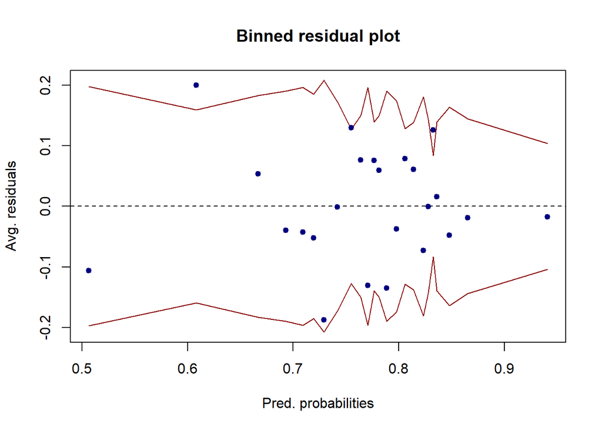

```
##
## Call:
## glm(formula = inc78_factor ~ treat + age + educ + black + hispan +
##     married + nodegree, family = binomial, data = income)
##
## Deviance Residuals:
##     Min       1Q   Median       3Q      Max
## -2.0628   0.5189   0.6296   0.7582   1.2122
##
## Coefficients:
##             Estimate Std. Error z value Pr(>|z|)
## (Intercept)  1.39368    0.81532   1.709   0.0874 .
## treat1       0.31236    0.26508   1.178   0.2387
## age         -0.03186    0.01031  -3.090   0.0020 **
## educ         0.06285    0.05235   1.200   0.2299
## black1      -0.58597    0.25958  -2.257   0.0240 *
## hispan1      0.27446    0.36090   0.760   0.4470
## married1     0.31137    0.22893   1.360   0.1738
## nodegree1    0.07838    0.29256   0.268   0.7888
## ---
## Signif. codes:  0 '***' 0.001 '**' 0.01 '*' 0.05 '.' 0.1 ' ' 1
##
## (Dispersion parameter for binomial family taken to be 1)
##
##     Null deviance: 666.50  on 613  degrees of freedom
## Residual deviance: 644.86  on 606  degrees of freedom
## AIC: 660.86
##
## Number of Fisher Scoring iterations: 4
```

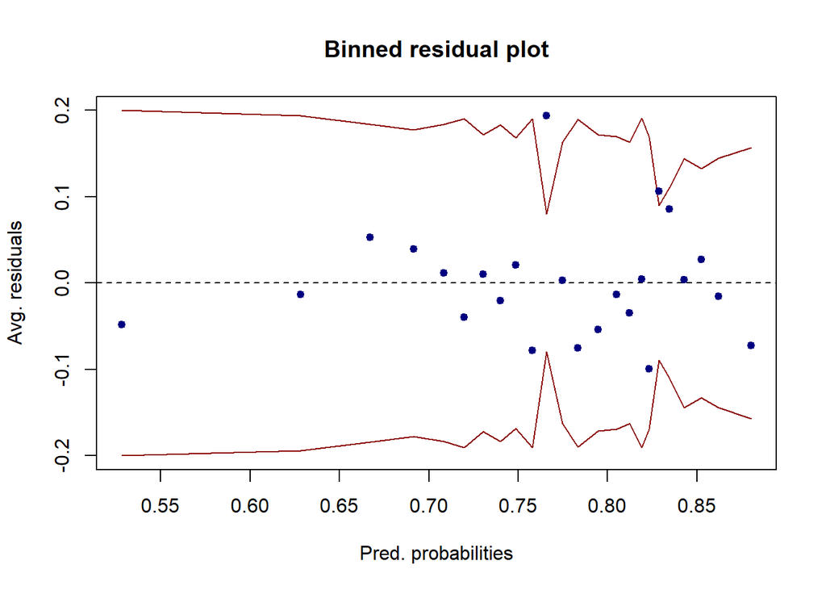

```
## Analysis of Deviance Table
##
## Model 1: inc78_factor ~ age + black
## Model 2: inc78_factor ~ treat + age + black
##   Resid. Df Resid. Dev Df Deviance Pr(>Chi)
## 1       611     650.05
## 2       610     648.77  1   1.2791   0.2581
```

```
## Analysis of Deviance Table
##
## Model 1: inc78_factor ~ age + treat * black
## Model 2: inc78_factor ~ age + black
##   Resid. Df Resid. Dev Df Deviance Pr(>Chi)
## 1       609     646.65
## 2       611     650.05 -2  -3.3924   0.1834
```

```
## Analysis of Deviance Table
##
## Model 1: inc78_factor ~ age + black + treat * hispan
## Model 2: inc78_factor ~ age + black
##   Resid. Df Resid. Dev Df Deviance Pr(>Chi)
## 1       608     645.36
## 2       611     650.05 -3   -4.683   0.1965
```

```
## Analysis of Deviance Table
##
## Model 1: inc78_factor ~ black + treat * age
## Model 2: inc78_factor ~ age + black
##   Resid. Df Resid. Dev Df Deviance Pr(>Chi)
## 1       609     643.51
## 2       611     650.05 -2  -6.5314  0.03817 *
## ---
## Signif. codes:  0 '***' 0.001 '**' 0.01 '*' 0.05 '.' 0.1 ' ' 1
```

```
## Analysis of Deviance Table
##
## Model 1: inc78_factor ~ age + black + treat * educ
## Model 2: inc78_factor ~ age + black
##   Resid. Df Resid. Dev Df Deviance Pr(>Chi)
## 1       608     647.25
## 2       611     650.05 -3  -2.7957   0.4242
```

```
## Analysis of Deviance Table
##
## Model 1: inc78_factor ~ age + black + treat * married
## Model 2: inc78_factor ~ age + black
##   Resid. Df Resid. Dev Df Deviance Pr(>Chi)
## 1       608     644.87
## 2       611     650.05 -3  -5.1781   0.1592
```

```
## Analysis of Deviance Table
##
## Model 1: inc78_factor ~ age + black + treat * nodegree
## Model 2: inc78_factor ~ age + black
##   Resid. Df Resid. Dev Df Deviance Pr(>Chi)
## 1       608     648.00
## 2       611     650.05 -3  -2.0478   0.5625
```

```
## Analysis of Deviance Table
##
## Model 1: inc78_factor ~ treat + black + age * nodegree
## Model 2: inc78_factor ~ age + black + treat * nodegree
##   Resid. Df Resid. Dev Df Deviance Pr(>Chi)
## 1       608     645.29
## 2       608     648.00  0  -2.7027
```

```
## Analysis of Deviance Table
##
## Model 1: inc78_factor ~ black + age * nodegree
## Model 2: inc78_factor ~ age + black
##   Resid. Df Resid. Dev Df Deviance Pr(>Chi)
## 1       609     646.43
## 2       611     650.05 -2  -3.6191   0.1637
```

#### **3.2 Final Model**

```
##     black     treat       age treat:age
##  1.585678 12.726543  1.244886 12.071304
```

```
##
## Call:
## glm(formula = inc78_factor ~ black + treat * age, family = binomial,
##     data = income)
##
## Deviance Residuals:
##     Min       1Q   Median       3Q      Max
## -2.0269   0.5238   0.6187   0.7768   1.2629
##
## Coefficients:
##             Estimate Std. Error z value Pr(>|z|)
## (Intercept)  2.55815    0.34734   7.365 1.77e-13 ***
## black1      -0.75298    0.24616  -3.059  0.00222 **
## treat1      -1.28872    0.74558  -1.728  0.08390 .
## age         -0.04008    0.01036  -3.867  0.00011 ***
## treat1:age   0.06038    0.02722   2.218  0.02655 *
## ---
## Signif. codes:  0 '***' 0.001 '**' 0.01 '*' 0.05 '.' 0.1 ' ' 1
##
## (Dispersion parameter for binomial family taken to be 1)
##
##     Null deviance: 666.50  on 613  degrees of freedom
## Residual deviance: 643.51  on 609  degrees of freedom
## AIC: 653.51
##
## Number of Fisher Scoring iterations: 4
```

```
## (Intercept)      black1      treat1         age  treat1:age
##  12.9118518   0.4709623   0.2756235   0.9607158   1.0622401
```

```
##                    5 %       95 %
## (Intercept) 7.36252760 23.1183472
## black1      0.31375536  0.7059151
## treat1      0.07951791  0.9303604
## age         0.94439910  0.9772091
## treat1:age  1.01685747  1.1125700
```

#### **3.3 Model Assessment**

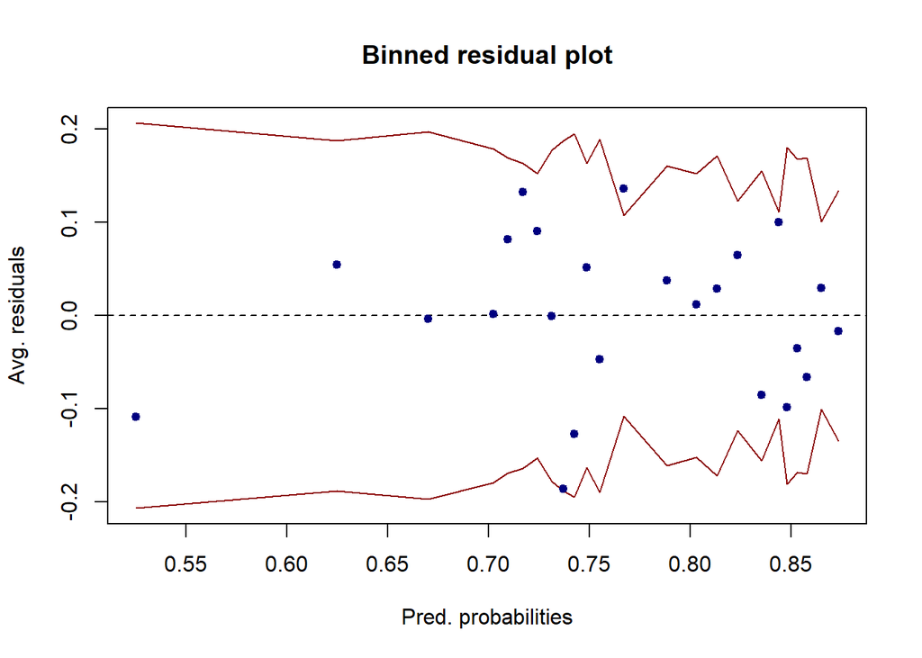

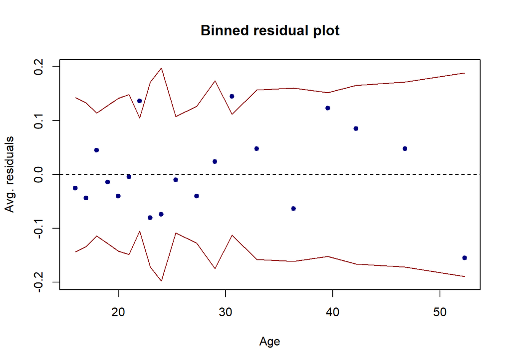

#### **3.4 Model Validation**

For model validation, we used a 2x2 confusion matrix for evaluate the performance of out final model. According to the matrix, we got an accuracy of 0.77 which means 77% of the observation are correctly classified by the model. The sensitivity of the test reflects the probability that the prediction will be positive (having non-zero wage) among those who do have non-zero earnings. A 0.99 sensitivity indicates a great true-positive rate of the model. However, the model is less efficient for a correct accurate results when the worker does not have a positive earning since the specificity rate is very low.

##### **Confusion matrix: Threshold = 0.5, final model**

[output not shown]

```
##           Reference
## Prediction   0   1
##          0   6   4
##          1 137 467
```

```
##  Accuracy
## 0.7703583
```

```
## Sensitivity Specificity
##  0.99150743  0.04195804
```

##### **ROC curve: final model vs model with all predictors**

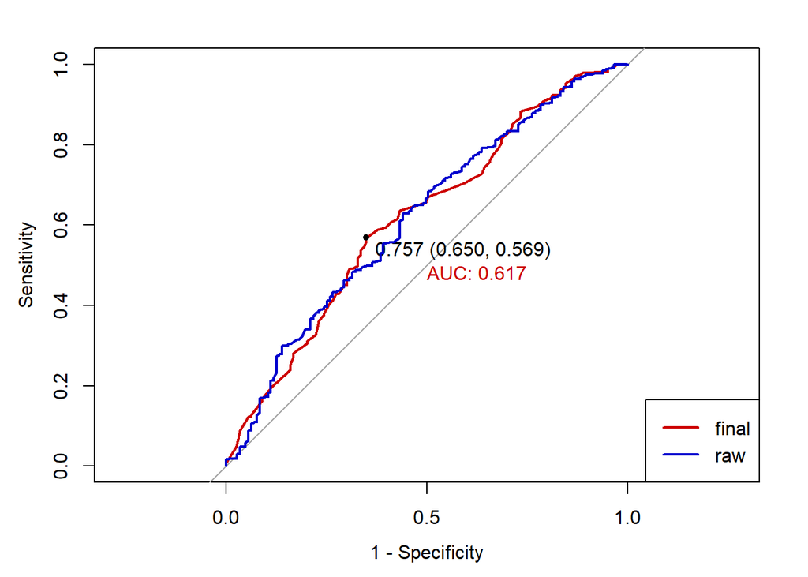